# R survival analysis example

# 1 load the libraries and dataset

## 1.1 Libraries

```r
library(tidyverse)
library(survival)
library(survminer)
library(knitr)
library(kableExtra)
library(rlang)
library(ggpubr)
```

## 1.2 Dataset

The dataset `lung` we are using in the example is also from the package `survival`.

1. `inst`: Institution code
2. **`time`: Survival time in days**
3. **`status`: censoring status 1=censored, 2=dead**
4. `age`: Age in years
5. **`sex`: Male=1 Female=2**
6. `ph.ecog`: ECOG performance score (0=good 5=dead)
7. `ph.karno`: Karnofsky performance score as rated by physician
8. `pat.karno`: Karnofsky performance score as rated by patient
9. `meal.cal`: Calories consumed at meals
10. `wt.loss`: Weight loss in last six months

Let’s add some more columns to the dataset: 1. Convert the column `sex` from value `1`/`2` to `Male`/`Female`. Set `Male` as the reference. 1. Divide the age into two groups by its median. Set `Young` as the reference.

Setting ref level is required as in Cox model we usually need to run the statistical analysis for pre-defined contrasts.

```r
lung_dataset = lung %>%
  mutate(sex = ifelse(sex == 1, "Male", "Female"),
         age_group = ifelse(age < median(age, na.rm = TRUE), "Young", "Old")) %>%
  mutate(sex = fct_relevel(sex, "Male"),
         age_group = fct_relevel(age_group, "Young"))
```

# 2 Kaplan-Meier plot

## 2.1 One Kaplan-Meier plot

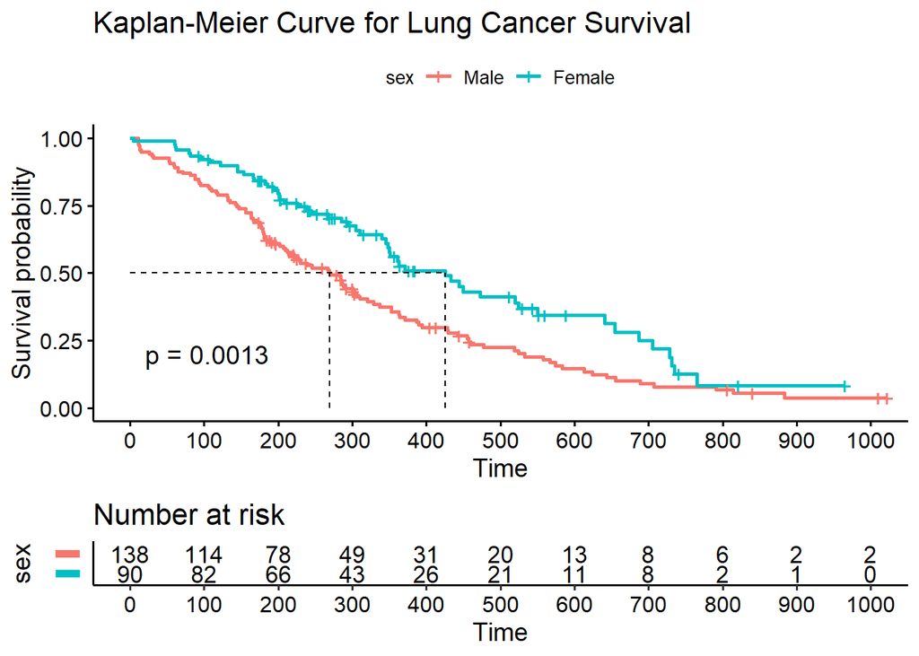

```r
fit <- surv_fit(Surv(time, status) ~ sex, data = lung_dataset)
ggsurvplot(fit,
           risk.table = TRUE, tables.y.text = FALSE, break.x.by = 100,
            pval = TRUE, surv.median.line = "hv",
           legend.title = "sex", legend.labs = levels(lung_dataset$sex),
           title = "Kaplan-Meier Curve for Lung Cancer Survival")
```

Note that here we use `surv_fit` rather than the standard `survfit` as `surv_fit`is a wrapper of `survfit` with more supports.

## 2.2 Mulitiple Kaplan-Meier plots

When it comes to mulitple plots, we can save each KM plot into a list and use `arrange_ggsurvplots` function.

Here we want to draw the KM plots based on the variable sex and age_group.

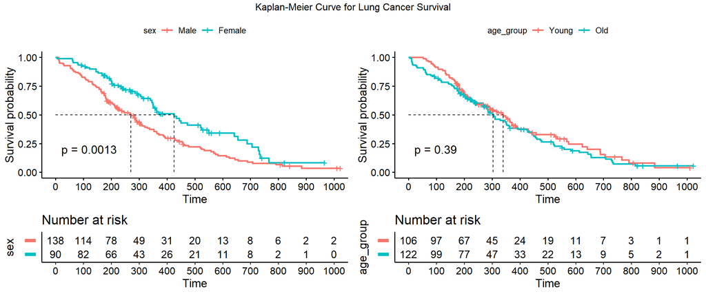

```r
KM_plots = list()
i = 1

for (strata_variable in c('sex', 'age_group')){
  surv_formula = paste0("Surv(time, status)~", strata_variable) %>%
    as.formula()

  fit = surv_fit(surv_formula, data = lung_dataset)

  KM_plots[[i]] = ggsurvplot(fit,
                             risk.table = TRUE, tables.y.text = FALSE, break.x.by = 100,
                             pval = TRUE, surv.median.line = "hv",
                             legend.title = strata_variable,
                             legend.labs = levels(lung_dataset[, strata_variable]))
  i = i+1
}

arrange_ggsurvplots(KM_plots,risk.table.height = 0.3, title = 'Kaplan-Meier Curve for Lung Cancer Survival')
```

# 3 Median survival time

```r
#---- define the formula ----
surv_formula = as.formula("Surv(time, status) ~ sex")
fit = surv_fit(formula = surv_formula, data = lung_dataset, conf.type = "log-log")

#---- get the median ----
surv_result= summary(fit)$table %>% data.frame
surv_median = cbind("Feature" = rownames(surv_result), surv_result) %>%
  mutate(`Median [95% CI]` = paste0(median,' [', round(X0.95LCL, 1), ', ', round(X0.95UCL, 1), ']')) %>%
  select(Feature, records, events, `Median [95% CI]`)

kable(surv_median, row.names = FALSE) %>% kable_styling()
```

| Feature | records | events | Median [95% CI] |
| --- | --- | --- | --- |
| sex=Male | 138 | 112 | 270 [210, 306] |
| sex=Female | 90 | 53 | 426 [345, 524] |

# 4 Survival probability at given time

```r
#---- define the formula ----
given_time = 300

strata_variable = "sex"
surv_formula = paste0("Surv(time, status)~", strata_variable) %>%
    as.formula()
fit = surv_fit(formula = surv_formula, data = lung_dataset, conf.type = "log-log")

survival_p_raw = summary(fit, times =given_time)

survival_p = data.frame(
    Feature = survival_p_raw$strata,
    time = survival_p_raw$time,
    risk = survival_p_raw$n.risk,
    events = survival_p_raw$n.event,
    survival_rate = survival_p_raw$surv,
    lower_CI = survival_p_raw$lower,
    upper_CI = survival_p_raw$upper) %>%
  mutate_if(is.numeric, round, 3) %>%
  mutate(survival_rate_95CI = paste0(survival_rate, ' [', lower_CI, ', ', upper_CI,']')) %>%
  select(-survival_rate, -lower_CI, -upper_CI)

kable(survival_p) %>% kable_styling()
```

| Feature | time | risk | events | survival_rate_95CI |
| --- | --- | --- | --- | --- |
| sex=Male | 300 | 49 | 74 | 0.441 [0.354, 0.525] |
| sex=Female | 300 | 43 | 27 | 0.674 [0.56, 0.765] |

# 5 Cox model to get HR median

```r
#---- define the formula ----

strata_variable = "sex"
ref_level = levels(lung_dataset[, strata_variable])[1]
surv_formula = paste0("Surv(time, status)~", strata_variable) %>%
    as.formula()

#--- get the cox model ----

cox_model = coxph(formula = surv_formula, data=lung_dataset, method = 'efron')
cox_model_result = summary(cox_model)
cox_HR_CI = cox_model_result$conf.int
cox_result = data.frame(Contrast = rownames(cox_HR_CI),
                              Median = cox_HR_CI[, 'exp(coef)'],
                              Lower95 = cox_HR_CI[, 'lower .95'],
                              Upper95 = cox_HR_CI[, 'upper .95'],
                              Pvalue = cox_model_result$coefficients[,'Pr(>|z|)']) %>%
  mutate_if(is.numeric, round, 3) %>%
  mutate(Contrast = gsub(pattern = paste0(strata_variable,"(.+)"),
                         replacement = paste0(strata_variable, ": \\1 vs. ", ref_level),
                         Contrast))

kable(cox_result) %>% kable_styling()
```

| Contrast | Median | Lower95 | Upper95 | Pvalue |
| --- | --- | --- | --- | --- |
| sex: Female vs. Male | 0.588 | 0.424 | 0.816 | 0.001 |

# 6 Box plot

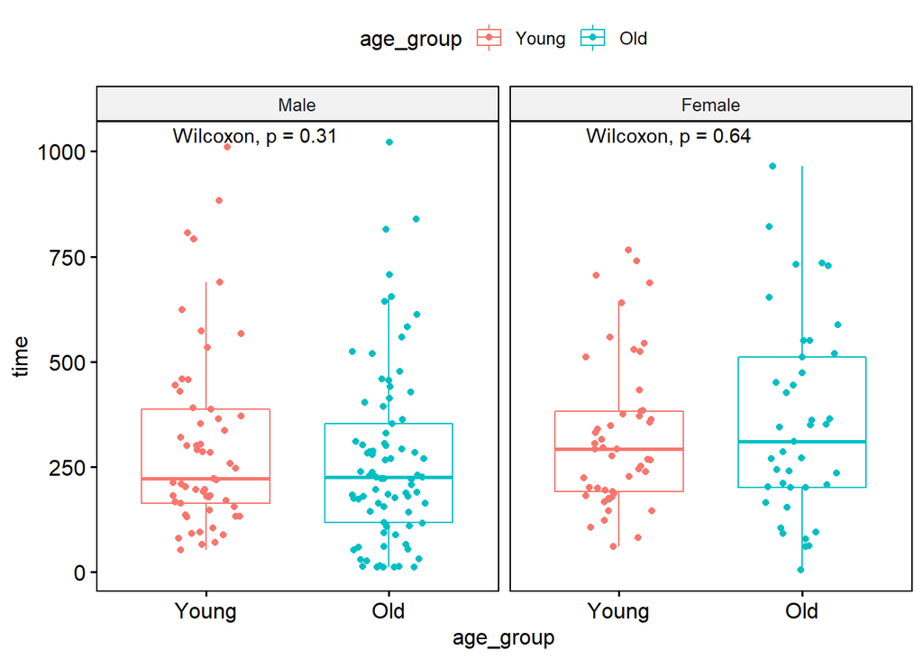

```r
lung_dataset %>%
  ggboxplot(x='age_group',
            y='time',
            facet.by = 'sex',
            add = 'jitter',
            color = 'age_group')+
  stat_compare_means() + ylab('time')
```

# 7 Some data manipulation tips

## 7.1 `dplyr` library with variable

When we are manipulate a dataset with `dplyr`, we usually see something like `mutate(lung_dataset, new_age = scale(age))`. Here `new_age` and `age` are the column names in the dataset `lung_dataset`. This is called non-standard evaluation. So if we have many columns which need the same function, we can not do something like `mutate(lung_dataset, new_column = scale(old_column))` as `dplyr` tries to find the column called `old_column`. `dplyr` needs us to use the bang-bang sign (!!) to specify the variables.

```r
new_column = "new_age"
old_column = "age"
lung_dataset = lung_dataset %>%
  mutate(!!new_column := scale(!!sym(old_column)))
```